# Gam model: birthweight

### Try with mat age k=12 and month k=10

```r
m_BW_bam5_1 <- bam(BW ~ s(GA_weeks) +  s(mat_age, k=13) + s(birth_Y_M_num) + s(month, k=11) + s(mean_ssep2) + parity_cat + sex + Urban3 + Language + mother_nationality_cat2, data=bevn_eco_in7)
  summary(m_BW_bam5_1)
```

```
##
## Family: gaussian
## Link function: identity
##
## Formula:
## BW ~ s(GA_weeks) + s(mat_age, k = 13) + s(birth_Y_M_num) + s(month,
##     k = 11) + s(mean_ssep2) + parity_cat + sex + Urban3 + Language +
##     mother_nationality_cat2
##
## Parametric coefficients:
##                                                       Estimate Std. Error  t value Pr(>|t|)
## (Intercept)                                          3335.2684     0.8361 3988.889  < 2e-16 ***
## parity_cat(1,2]                                       127.4692     0.8345  152.758  < 2e-16 ***
## parity_cat(2,3]                                       173.6232     1.2772  135.937  < 2e-16 ***
## parity_cat(3,20]                                      199.6911     2.2149   90.157  < 2e-16 ***
## sex2                                                 -147.0104     0.7458 -197.129  < 2e-16 ***
## Urban3                                                  0.6595     0.7906    0.834    0.404
## LanguageFrench                                        -48.0926     0.9182  -52.374  < 2e-16 ***
## LanguageItalian                                       -63.1901     2.0493  -30.835  < 2e-16 ***
## mother_nationality_cat2Africa                          11.0235     2.2735    4.849 1.24e-06 ***
## mother_nationality_cat2Asia                           -17.9212     2.0596   -8.702  < 2e-16 ***
## mother_nationality_cat2Europe                          32.5734     0.8501   38.316  < 2e-16 ***
## mother_nationality_cat2Northern America                65.0139     4.8546   13.392  < 2e-16 ***
## mother_nationality_cat2Oceania                         63.4734    11.1288    5.704 1.17e-08 ***
## mother_nationality_cat2Southern and Central America    47.0408     2.7991   16.806  < 2e-16 ***
## ---
## Signif. codes:  0 '***' 0.001 '**' 0.01 '*' 0.05 '.' 0.1 ' ' 1
##
## Approximate significance of smooth terms:
##                    edf Ref.df         F p-value
## s(GA_weeks)      8.828  8.988 73215.198 < 2e-16 ***
## s(mat_age)       6.568  7.836    14.641 < 2e-16 ***
## s(birth_Y_M_num) 8.285  8.859    39.006 < 2e-16 ***
## s(month)         5.978  7.248     3.072 0.00277 **
## s(mean_ssep2)    7.634  8.534    43.676 < 2e-16 ***
## ---
## Signif. codes:  0 '***' 0.001 '**' 0.01 '*' 0.05 '.' 0.1 ' ' 1
##
## R-sq.(adj) =  0.401   Deviance explained = 40.1%
## fREML = 8.1205e+06  Scale est. = 1.5259e+05  n = 1099328
```

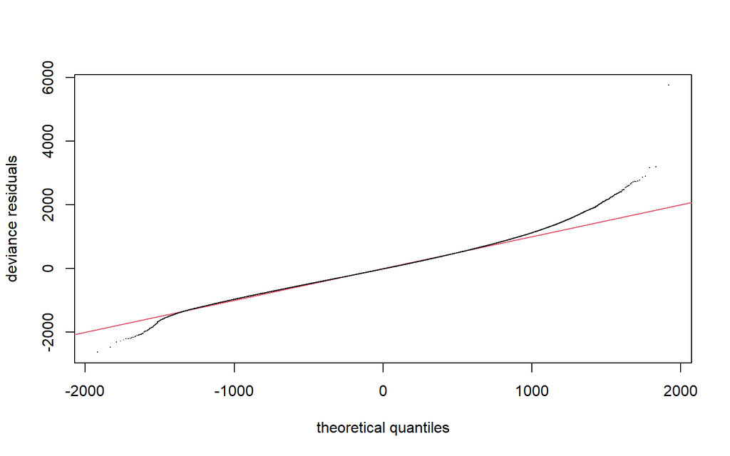

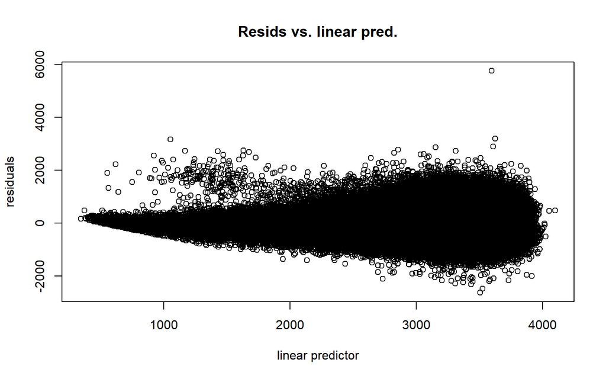

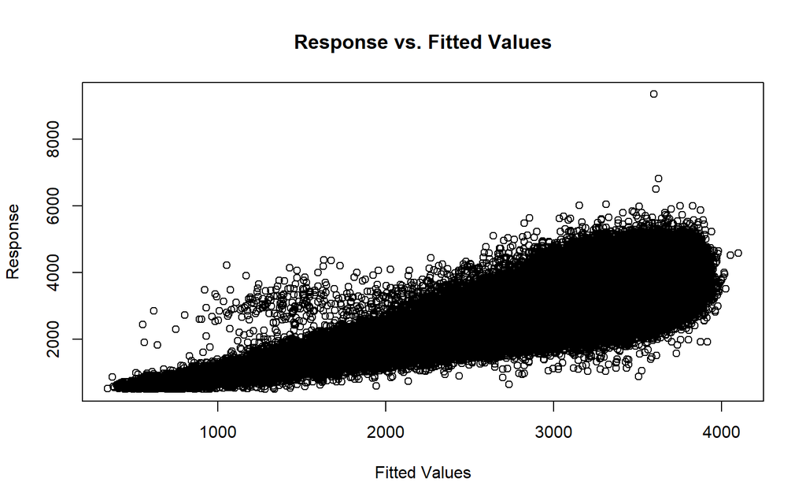

```
##
## Method: fREML   Optimizer: perf newton
## full convergence after 11 iterations.
## Gradient range [-0.0009357942,0.0007208003]
## (score 8120452 & scale 152595).
## Hessian positive definite, eigenvalue range [1.648423,549654.5].
## Model rank =  63 / 63
##
## Basis dimension (k) checking results. Low p-value (k-index<1) may
## indicate that k is too low, especially if edf is close to k'.
##
##                     k'   edf k-index p-value
## s(GA_weeks)       9.00  8.83    0.96  <2e-16 ***
## s(mat_age)       12.00  6.57    1.00    0.67
## s(birth_Y_M_num)  9.00  8.28    1.02    0.86
## s(month)         10.00  5.98    1.01    0.61
## s(mean_ssep2)     9.00  7.63    1.01    0.80
## ---
## Signif. codes:  0 '***' 0.001 '**' 0.01 '*' 0.05 '.' 0.1 ' ' 1
```

```r
  gam.check(m_BW_bam5_1)
```

```r
  concurvity(m_BW_bam5_1, full=TRUE)
```

```
##               para s(GA_weeks) s(mat_age) s(birth_Y_M_num)    s(month) s(mean_ssep2)
## worst    0.8015963 0.017211066 0.12307439      0.030165524 0.028070793    0.17908212
## observed 0.8015963 0.006386136 0.04255397      0.007228201 0.002163185    0.10239354
## estimate 0.8015963 0.009760255 0.07758667      0.011469079 0.019775195    0.08954325
```

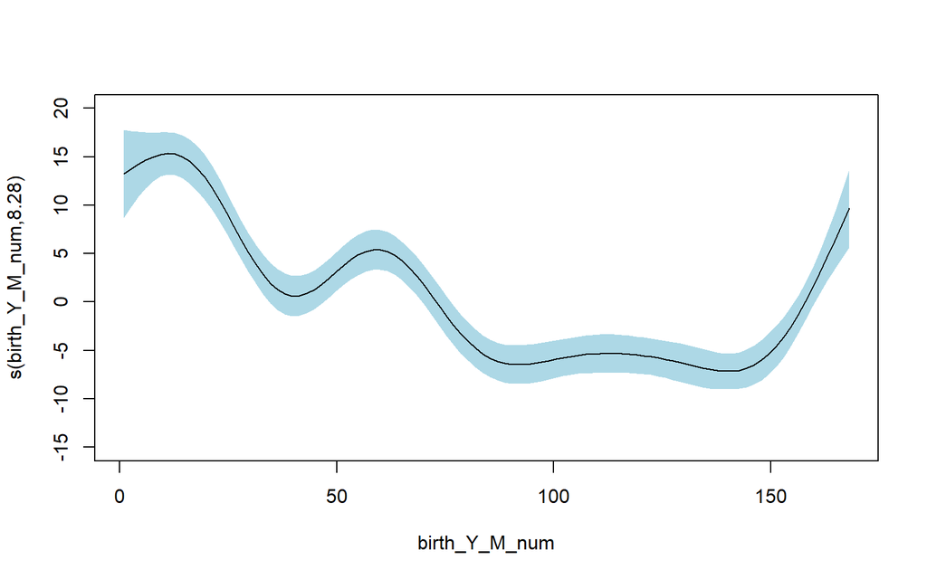

```r
  #from the "worst" case, the values are not high (high would be >0.8, usually)
  plot(m_BW_bam5_1, select=3, ylim=c(-15, 20), shade = TRUE, shade.col = "lightblue")
```

### Chosen GAM model for birthweight:

Lower k for mat age (6 basis functions means k=7) to avoid overfitting

```r
  m_BW_bam5_2 <- bam(BW ~ s(GA_weeks) +  s(mat_age, k=7) + s(birth_Y_M_num) + s(month) + s(mean_ssep2) + parity_cat + sex + Urban3 + Language + mother_nationality_cat2, data=bevn_eco_in7)
  summary(m_BW_bam5_2)
```

```
##
## Family: gaussian
## Link function: identity
##
## Formula:
## BW ~ s(GA_weeks) + s(mat_age, k = 7) + s(birth_Y_M_num) + s(month) +
##     s(mean_ssep2) + parity_cat + sex + Urban3 + Language + mother_nationality_cat2
##
## Parametric coefficients:
##                                                       Estimate Std. Error  t value Pr(>|t|)
## (Intercept)                                          3335.2704     0.8361 3989.044  < 2e-16 ***
## parity_cat(1,2]                                       127.4692     0.8344  152.762  < 2e-16 ***
## parity_cat(2,3]                                       173.6260     1.2772  135.939  < 2e-16 ***
## parity_cat(3,20]                                      199.6977     2.2149   90.160  < 2e-16 ***
## sex2                                                 -147.0101     0.7458 -197.128  < 2e-16 ***
## Urban3                                                  0.6608     0.7906    0.836    0.403
## LanguageFrench                                        -48.0924     0.9182  -52.374  < 2e-16 ***
## LanguageItalian                                       -63.1878     2.0493  -30.834  < 2e-16 ***
## mother_nationality_cat2Africa                          11.0168     2.2735    4.846 1.26e-06 ***
## mother_nationality_cat2Asia                           -17.9253     2.0596   -8.703  < 2e-16 ***
## mother_nationality_cat2Europe                          32.5679     0.8501   38.310  < 2e-16 ***
## mother_nationality_cat2Northern America                65.0093     4.8546   13.391  < 2e-16 ***
## mother_nationality_cat2Oceania                         63.4678    11.1288    5.703 1.18e-08 ***
## mother_nationality_cat2Southern and Central America    47.0493     2.7991   16.809  < 2e-16 ***
## ---
## Signif. codes:  0 '***' 0.001 '**' 0.01 '*' 0.05 '.' 0.1 ' ' 1
##
## Approximate significance of smooth terms:
##                    edf Ref.df         F p-value
## s(GA_weeks)      8.826  8.988 73217.048  <2e-16 ***
## s(mat_age)       5.178  5.693    20.286  <2e-16 ***
## s(birth_Y_M_num) 8.285  8.859    39.009  <2e-16 ***
## s(month)         5.893  7.053     3.183  0.0022 **
## s(mean_ssep2)    7.634  8.534    43.693  <2e-16 ***
## ---
## Signif. codes:  0 '***' 0.001 '**' 0.01 '*' 0.05 '.' 0.1 ' ' 1
##
## R-sq.(adj) =  0.401   Deviance explained = 40.1%
## fREML = 8.1205e+06  Scale est. = 1.5259e+05  n = 1099328
```

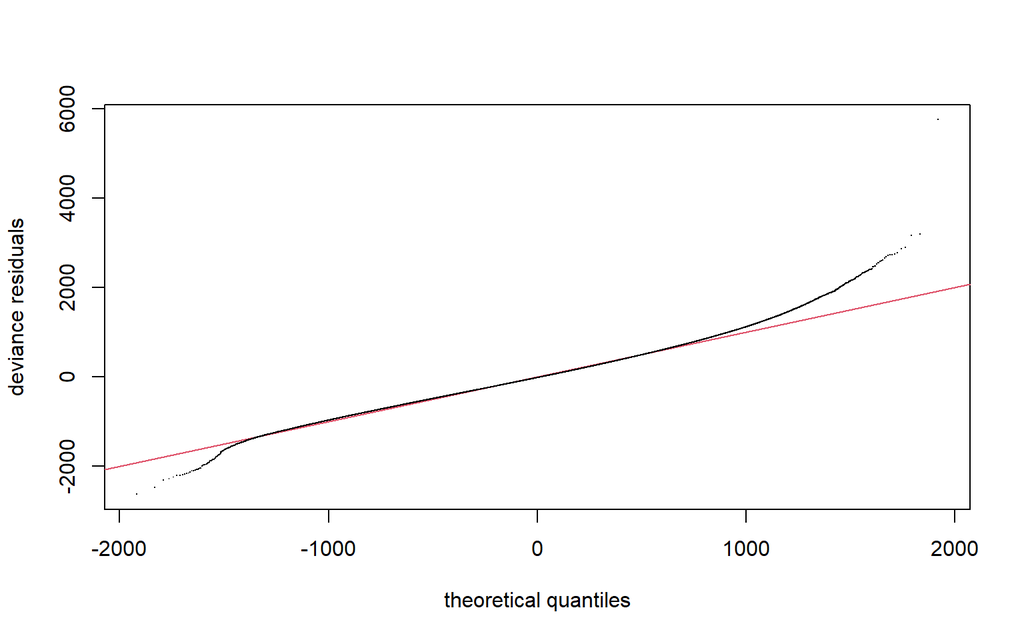

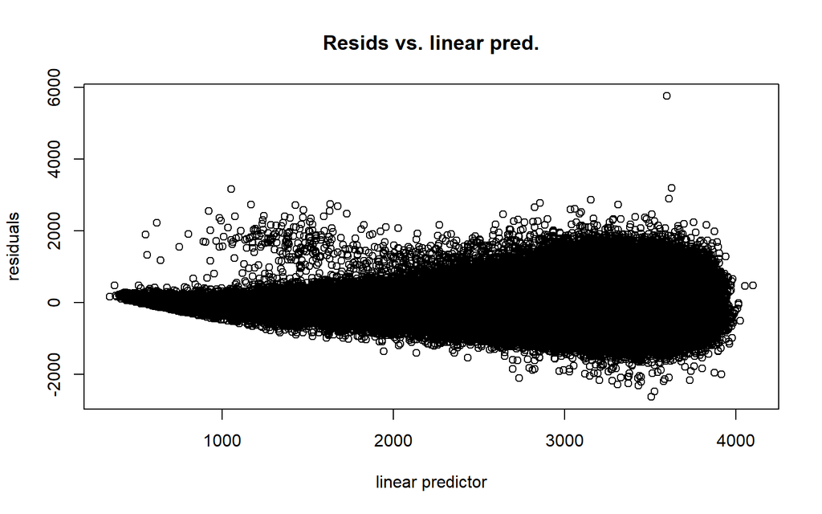

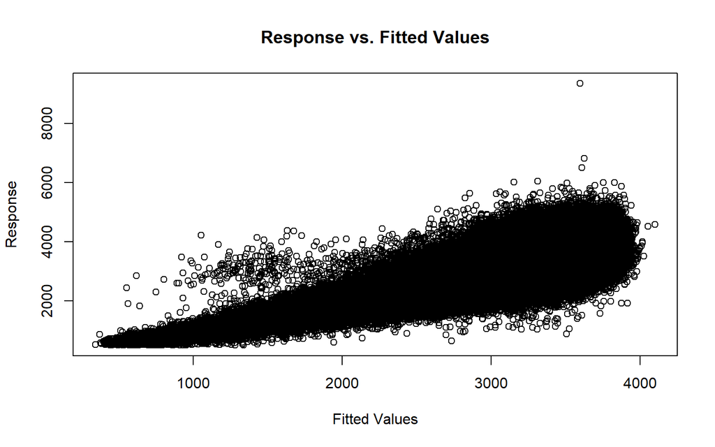

```
##
## Method: fREML   Optimizer: perf newton
## full convergence after 11 iterations.
## Gradient range [-0.07345475,0.05455442]
## (score 8120451 & scale 152594.7).
## Hessian positive definite, eigenvalue range [1.608974,549654.6].
## Model rank =  56 / 56
##
## Basis dimension (k) checking results. Low p-value (k-index<1) may
## indicate that k is too low, especially if edf is close to k'.
##
##                    k'  edf k-index p-value
## s(GA_weeks)      9.00 8.83    0.99    0.31
## s(mat_age)       6.00 5.18    1.02    0.92
## s(birth_Y_M_num) 9.00 8.28    1.00    0.37
## s(month)         9.00 5.89    1.01    0.74
## s(mean_ssep2)    9.00 7.63    1.02    0.84
```

```r
  gam.check(m_BW_bam5_2)
```

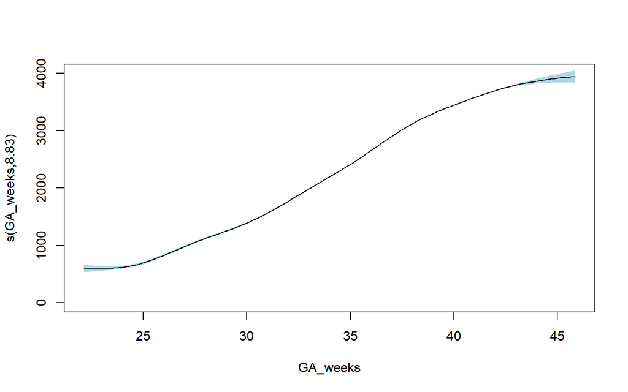

```r
  plot(m_BW_bam5_2, select=1, ylim=c(0, 4000),shade = TRUE, shade.col = "lightblue",  shift = coef(m_BW_bam5)[1])
```

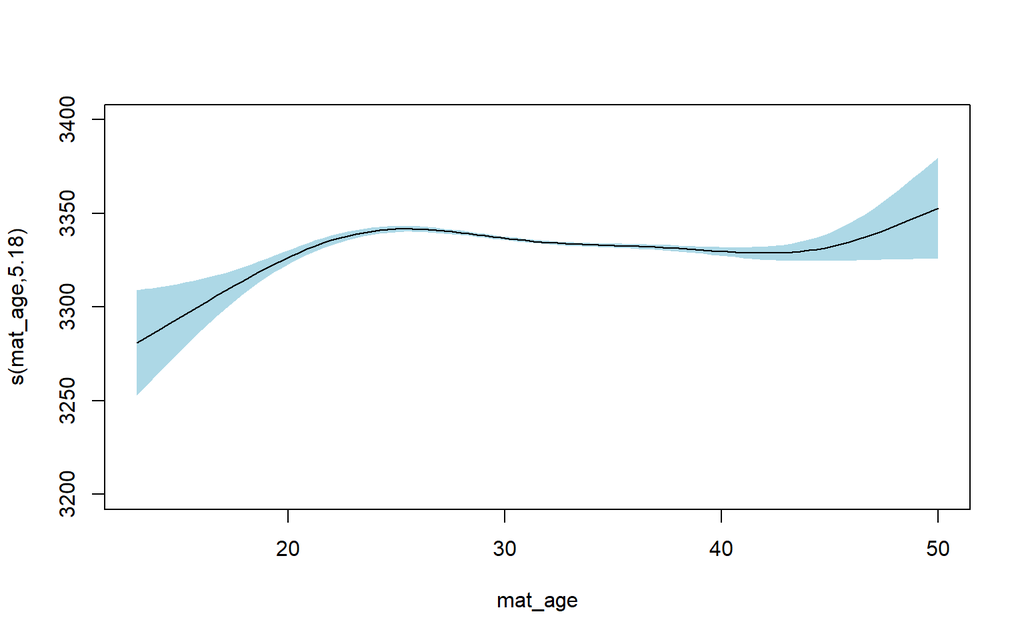

```r
  plot(m_BW_bam5_2, select=2, ylim=c(3200, 3400),shade = TRUE, shade.col = "lightblue",  shift = coef(m_BW_bam5_2)[1])
```

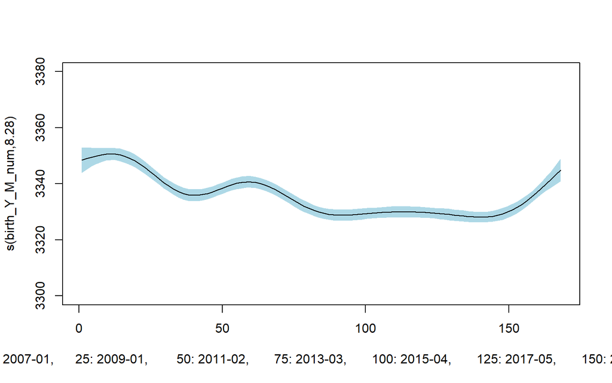

```r
  plot(m_BW_bam5_2, select=3, ylim=c(3300, 3380),shade = TRUE, shade.col = "lightblue",  shift = coef(m_BW_bam5_2)[1]  ,  xlab  = "0 : 2007-01,      25: 2009-01,        50: 2011-02,       75: 2013-03,       100: 2015-04,       125: 2017-05,       150: 2019-06"
)
```

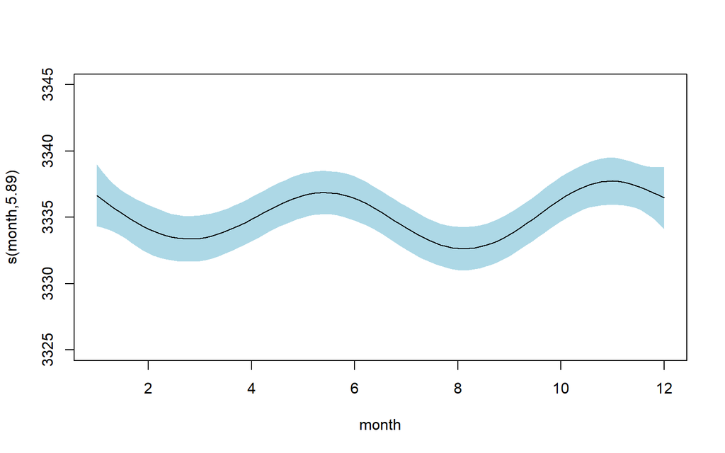

```r
  plot(m_BW_bam5_2, select=4, ylim=c(3325, 3345),shade = TRUE, shade.col = "lightblue",  shift = coef(m_BW_bam5_2)[1])
```

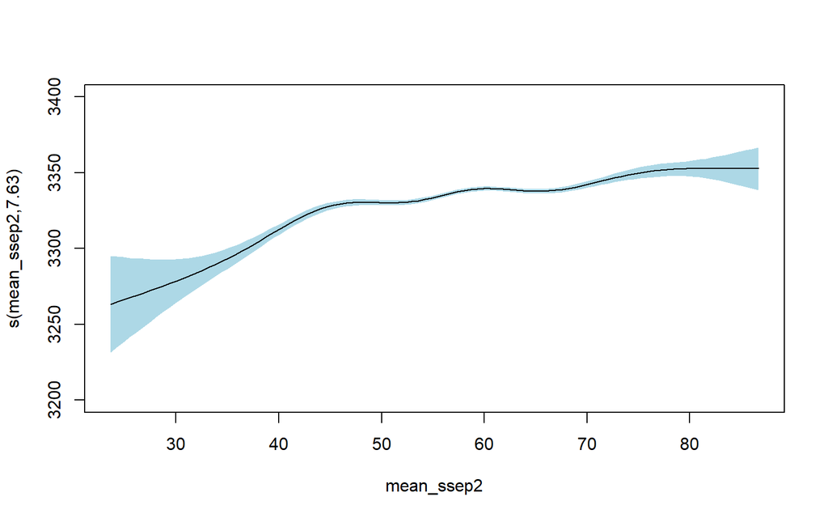

```r
  plot(m_BW_bam5_2, select=5, ylim=c(3200, 3400),shade = TRUE, shade.col = "lightblue",  shift = coef(m_BW_bam5_2)[1])
```

```r
  #getting the CI 95% (interpret only for the non-smooth parameters)
  beta <- coef(m_BW_bam5_2)
  Vb <- vcov(m_BW_bam5_2, unconditional = TRUE)
  se <- sqrt(diag(Vb))
  my.ci <- data.frame(cbind(beta, lci = beta-1.96*se, uci = beta + 1.96*se))
  round(head(my.ci,14), 2)
```

```
##                                                         beta     lci     uci
## (Intercept)                                          3335.27 3333.63 3336.91
## parity_cat(1,2]                                       127.47  125.83  129.10
## parity_cat(2,3]                                       173.63  171.12  176.13
## parity_cat(3,20]                                      199.70  195.36  204.04
## sex2                                                 -147.01 -148.47 -145.55
## Urban3                                                  0.66   -0.89    2.21
## LanguageFrench                                        -48.09  -49.89  -46.29
## LanguageItalian                                       -63.19  -67.20  -59.17
## mother_nationality_cat2Africa                          11.02    6.56   15.47
## mother_nationality_cat2Asia                           -17.93  -21.96  -13.89
## mother_nationality_cat2Europe                          32.57   30.90   34.23
## mother_nationality_cat2Northern America                65.01   55.49   74.52
## mother_nationality_cat2Oceania                         63.47   41.66   85.28
## mother_nationality_cat2Southern and Central America    47.05   41.56   52.54
```

```r
  #comparing models with different k parameters
  AIC(m_BW_bam5, m_BW_bam5_1, m_BW_bam5_2)
```

```
##                   df      AIC
## m_BW_bam5   53.45272 16240889
## m_BW_bam5_1 54.13589 16240891
## m_BW_bam5_2 52.67596 16240888
```

## Using mat. nationality category 3

```r
   m_BW_bam6 <- bam(BW ~ s(GA_weeks) +  s(mat_age, k=7) + s(birth_Y_M_num) + s(month, k=11) + s(mean_ssep2) + parity_cat + sex + Urban3 + Language + mother_nationality_cat3, data=bevn_eco_in7)
  summary(m_BW_bam6)
```

```
##
## Family: gaussian
## Link function: identity
##
## Formula:
## BW ~ s(GA_weeks) + s(mat_age, k = 7) + s(birth_Y_M_num) + s(month,
##     k = 11) + s(mean_ssep2) + parity_cat + sex + Urban3 + Language +
##     mother_nationality_cat3
##
## Parametric coefficients:
##                                         Estimate Std. Error  t value Pr(>|t|)
## (Intercept)                            3336.7310     0.8367 3987.742   <2e-16 ***
## parity_cat(1,2]                         125.8347     0.8355  150.602   <2e-16 ***
## parity_cat(2,3]                         169.0204     1.2812  131.919   <2e-16 ***
## parity_cat(3,20]                        193.4584     2.2145   87.359   <2e-16 ***
## sex2                                   -146.9709     0.7446 -197.379   <2e-16 ***
## Urban3                                    0.1923     0.7896    0.244    0.808
## LanguageFrench                          -38.6042     0.9461  -40.805   <2e-16 ***
## LanguageItalian                         -56.7385     2.0605  -27.536   <2e-16 ***
## mother_nationality_cat3Central Europe    44.5605     1.5104   29.503   <2e-16 ***
## mother_nationality_cat3Eastern Europe   101.9994     3.7786   26.994   <2e-16 ***
## mother_nationality_cat3Northern Europe   89.5542     5.9617   15.022   <2e-16 ***
## mother_nationality_cat3other             12.4670     1.3318    9.361   <2e-16 ***
## mother_nationality_cat3SE Europe         73.8012     1.4197   51.985   <2e-16 ***
## mother_nationality_cat3Southern Europe    2.4744     1.8727    1.321    0.186
## mother_nationality_cat3SW Europe        -46.9686     1.8041  -26.034   <2e-16 ***
## mother_nationality_cat3Western Europe    24.1626     2.1979   10.994   <2e-16 ***
## ---
## Signif. codes:  0 '***' 0.001 '**' 0.01 '*' 0.05 '.' 0.1 ' ' 1
##
## Approximate significance of smooth terms:
##                    edf Ref.df         F p-value
## s(GA_weeks)      8.866  8.993 73363.333  <2e-16 ***
## s(mat_age)       4.886  5.474    15.210  <2e-16 ***
## s(birth_Y_M_num) 8.311  8.868    40.089  <2e-16 ***
## s(month)         5.938  7.204     3.075  0.0028 **
## s(mean_ssep2)    7.410  8.389    36.498  <2e-16 ***
## ---
## Signif. codes:  0 '***' 0.001 '**' 0.01 '*' 0.05 '.' 0.1 ' ' 1
##
## R-sq.(adj) =  0.403   Deviance explained = 40.3%
## fREML = 8.1191e+06  Scale est. = 1.5213e+05  n = 1099368
```

Interpretation of m_BW_bam5_2 model :

Why choosing m_BW_bam5_2? It has the lowest AIC and also lower k value for maternal age, which seems more appropriate by looking at the graph.

- Non-smooth terms

Increasing parity increases birthweight, from 126,129g at second parity, 171,176g at third parity, to 195-204g for parities over 3.

Being born female decreases by -148, -146g compared to males.

Urbanicity has no effect on birthweight.

Language: Compared to babies born in German(+Romansh)-speaking Switzerland, being born in the French-speaking part decreases BW by -50,-46g, while being born in the Italian-speaking part decreases BW by -67,-59g.

Maternal nationality: compared to babies born from Swiss mothers, babies born from Asian mothers are lighter -22g, -14g. Babies born from other-nationalites mothers are heavier: 7, 16g for Africa, 31, 34g for other European countries, 55, 75g for Northern America, 41,86g for Oceania, and 42-53g for Southern/Central America.

- Smooth terms

Maternal age: birthweight increases non-linearly with maternal age: for younger mothers (<25yo) it increases almost linearly from 3280g to 3350g, then declines very slightly until around 3340g when the mother is 25-40yo. Older women have heavier babies, increasing from 3340g to around 3360g for women 40-50yo (keep in mind we have excluded a few mothers above 50 - improbable).

Time (month+year combined): globally, birthweight is decreasing between 2007 and 2019 from 3350 to 3330 which is a minor change, and then increases from 2019 to reach 3350g. There are some other minor variations throughtout the whole time but this doesnt seem very relevant: only 20g variation.

Seasonal/month: minor sinusoidal seasonal variation between 3330-3340g, with lower birthweight in March and August. These difference dont seem much relevant either (10g variation will probably not impact the baby’s health).

Mean ssep: Birthweight increases by increasing ssep, linearly between ssep=25-45 approx (3250-3340g), and then there is some minor birthweight increase for higher ssep, until reaching a BW of around 3360g. Overall, a +100g increase is probably worht mentioning.

# 2008-2010

```r
m_BW_bam_2009 <- bam(BW ~ s(GA_weeks) +  s(mat_age, k=7) + s(birth_Y_M_num) + s(month) + s(mean_ssep2) + parity_cat + sex + Urban3  + Language + mother_nationality_cat2, data=bevn_eco_in7_2008_10)
  summary(m_BW_bam_2009)
```

```
##
## Family: gaussian
## Link function: identity
##
## Formula:
## BW ~ s(GA_weeks) + s(mat_age, k = 7) + s(birth_Y_M_num) + s(month) +
##     s(mean_ssep2) + parity_cat + sex + Urban3 + Language + mother_nationality_cat2
##
## Parametric coefficients:
##                                                       Estimate Std. Error  t value Pr(>|t|)
## (Intercept)                                          3329.5292     1.8664 1783.931  < 2e-16 ***
## parity_cat(1,2]                                       122.2029     1.8848   64.835  < 2e-16 ***
## parity_cat(2,3]                                       172.3556     2.8839   59.764  < 2e-16 ***
## parity_cat(3,20]                                      196.5379     4.9231   39.921  < 2e-16 ***
## sex2                                                 -146.2367     1.6800  -87.046  < 2e-16 ***
## Urban3                                                  0.8122     1.7448    0.466  0.64156
## LanguageFrench                                        -46.0017     2.0609  -22.321  < 2e-16 ***
## LanguageItalian                                       -65.1691     4.3466  -14.993  < 2e-16 ***
## mother_nationality_cat2Africa                          41.2608     6.0376    6.834 8.28e-12 ***
## mother_nationality_cat2Asia                           -15.2951     4.9412   -3.095  0.00197 **
## mother_nationality_cat2Europe                          36.4673     1.9396   18.801  < 2e-16 ***
## mother_nationality_cat2Northern America                82.8386    10.6237    7.798 6.34e-15 ***
## mother_nationality_cat2Oceania                         54.2129    24.9694    2.171  0.02992 *
## mother_nationality_cat2Southern and Central America    60.6189     6.0057   10.094  < 2e-16 ***
## ---
## Signif. codes:  0 '***' 0.001 '**' 0.01 '*' 0.05 '.' 0.1 ' ' 1
##
## Approximate significance of smooth terms:
##                    edf Ref.df         F  p-value
## s(GA_weeks)      8.245  8.807 14715.201  < 2e-16 ***
## s(mat_age)       3.134  3.772     7.672 1.06e-05 ***
## s(birth_Y_M_num) 2.494  3.063    17.620  < 2e-16 ***
## s(month)         2.167  2.695     1.749    0.142
## s(mean_ssep2)    1.005  1.010    70.220  < 2e-16 ***
## ---
## Signif. codes:  0 '***' 0.001 '**' 0.01 '*' 0.05 '.' 0.1 ' ' 1
##
## R-sq.(adj) =  0.397   Deviance explained = 39.7%
## fREML = 1.6251e+06  Scale est. = 1.548e+05  n = 219790
```

```r
  concurvity(m_BW_bam_2009, full=TRUE)
```

```
##               para s(GA_weeks) s(mat_age) s(birth_Y_M_num)  s(month) s(mean_ssep2)
## worst    0.7985832 0.016089460 0.13814708       0.99860108 0.9986011    0.18027357
## observed 0.7985832 0.006547420 0.02787894       0.10041387 0.8761761    0.13961897
## estimate 0.7985832 0.009352891 0.08646256       0.09851634 0.7612559    0.08259477
```

Problem with birth_Y_M_num and month variables: values >>0.8, they correlate too much. Also, mean ssep can be used as a linear term

```r
  m_BW_bam_2009_2 <- bam(BW ~ s(GA_weeks) +  s(mat_age, k=7) + s(birth_Y_M_num) + parity_cat + sex + Urban3  + Language + mother_nationality_cat2, data=bevn_eco_in7_2008_10)
  summary(m_BW_bam_2009_2)
```

```
##
## Family: gaussian
## Link function: identity
##
## Formula:
## BW ~ s(GA_weeks) + s(mat_age, k = 7) + s(birth_Y_M_num) + parity_cat +
##     sex + Urban3 + Language + mother_nationality_cat2
##
## Parametric coefficients:
##                                                      Estimate Std. Error  t value Pr(>|t|)
## (Intercept)                                          3330.032      1.866 1784.806  < 2e-16 ***
## parity_cat(1,2]                                       121.453      1.883   64.492  < 2e-16 ***
## parity_cat(2,3]                                       170.531      2.877   59.280  < 2e-16 ***
## parity_cat(3,20]                                      193.626      4.912   39.423  < 2e-16 ***
## sex2                                                 -146.226      1.680  -87.026  < 2e-16 ***
## Urban3                                                  3.381      1.718    1.967  0.04913 *
## LanguageFrench                                        -50.347      1.995  -25.240  < 2e-16 ***
## LanguageItalian                                       -69.232      4.319  -16.028  < 2e-16 ***
## mother_nationality_cat2Africa                          41.104      6.039    6.807 1.00e-11 ***
## mother_nationality_cat2Asia                           -14.379      4.941   -2.910  0.00361 **
## mother_nationality_cat2Europe                          36.567      1.940   18.849  < 2e-16 ***
## mother_nationality_cat2Northern America                87.011     10.614    8.198 2.46e-16 ***
## mother_nationality_cat2Oceania                         58.131     24.969    2.328  0.01991 *
## mother_nationality_cat2Southern and Central America    61.817      6.005   10.294  < 2e-16 ***
## ---
## Signif. codes:  0 '***' 0.001 '**' 0.01 '*' 0.05 '.' 0.1 ' ' 1
##
## Approximate significance of smooth terms:
##                    edf Ref.df         F p-value
## s(GA_weeks)      8.250  8.810 14705.660  <2e-16 ***
## s(mat_age)       3.176  3.815     9.668  <2e-16 ***
## s(birth_Y_M_num) 2.787  3.469    14.986  <2e-16 ***
## ---
## Signif. codes:  0 '***' 0.001 '**' 0.01 '*' 0.05 '.' 0.1 ' ' 1
##
## R-sq.(adj) =  0.397   Deviance explained = 39.7%
## fREML = 1.6251e+06  Scale est. = 1.5485e+05  n = 219790
```

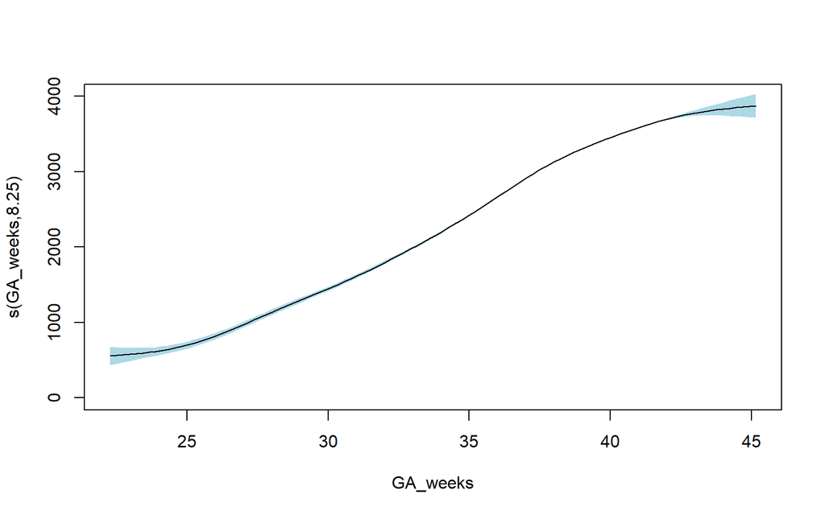

```r
   plot(m_BW_bam_2009_2, select=1, ylim=c(0, 4000),shade = TRUE, shade.col = "lightblue",shift = coef(m_BW_bam_2009)[1])
```

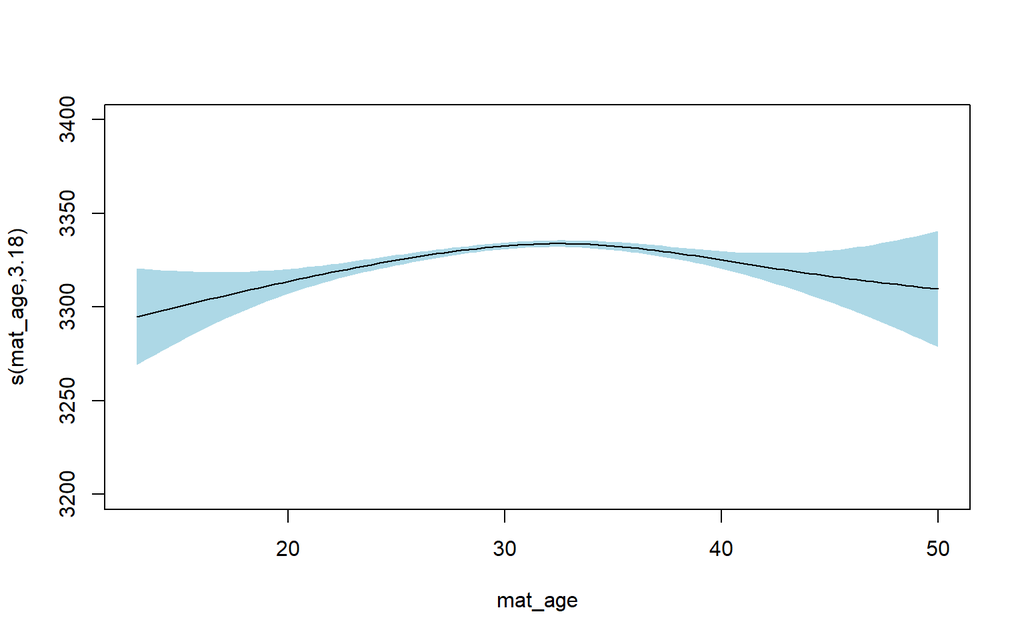

```r
  plot(m_BW_bam_2009_2, select=2, ylim=c(3200, 3400),shade = TRUE, shade.col = "lightblue",shift = coef(m_BW_bam_2009)[1])
```

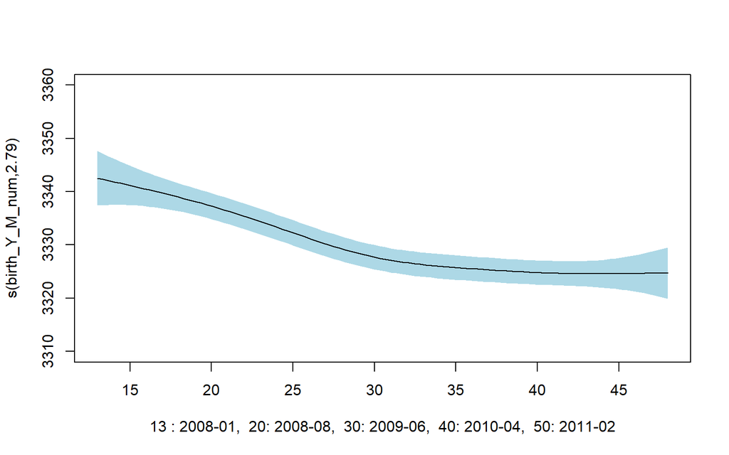

```r
  plot(m_BW_bam_2009_2, select=3, ylim=c(3310, 3360),shade = TRUE, shade.col = "lightblue", shift = coef(m_BW_bam_2009_2)[1],  xlab  = "13 : 2008-01,  20: 2008-08,  30: 2009-06,  40: 2010-04,  50: 2011-02")
```

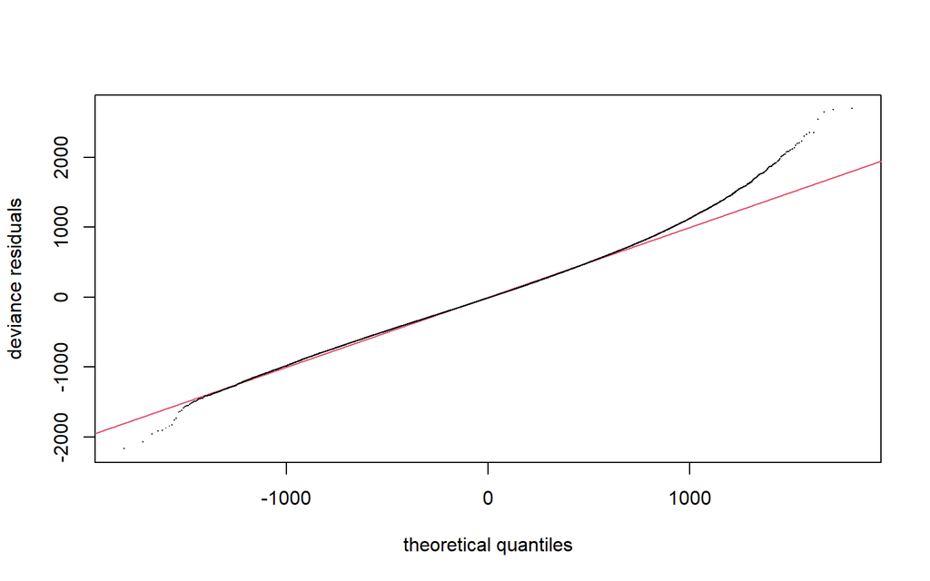

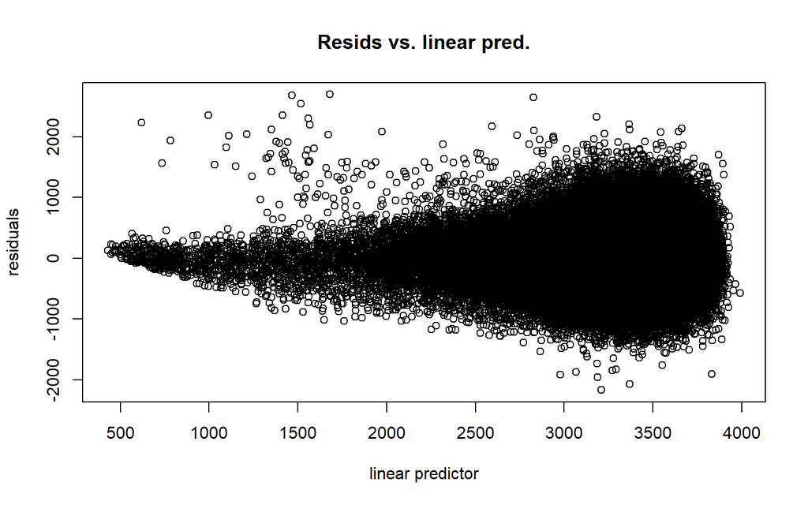

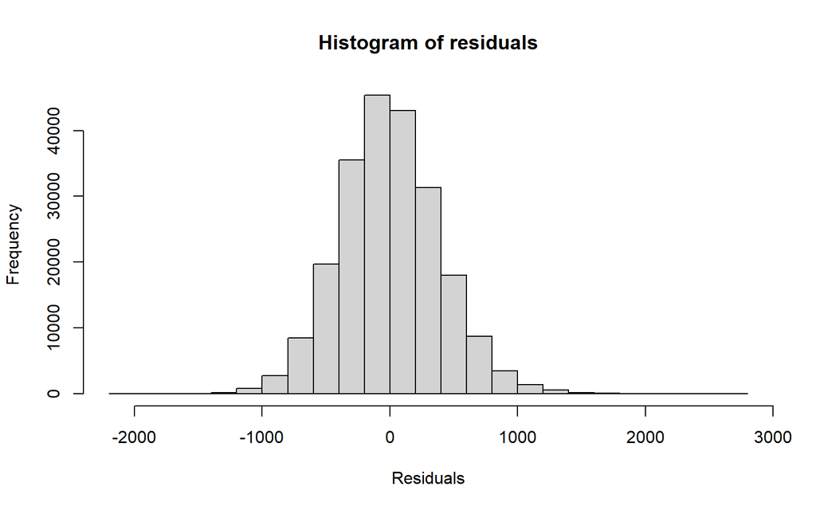

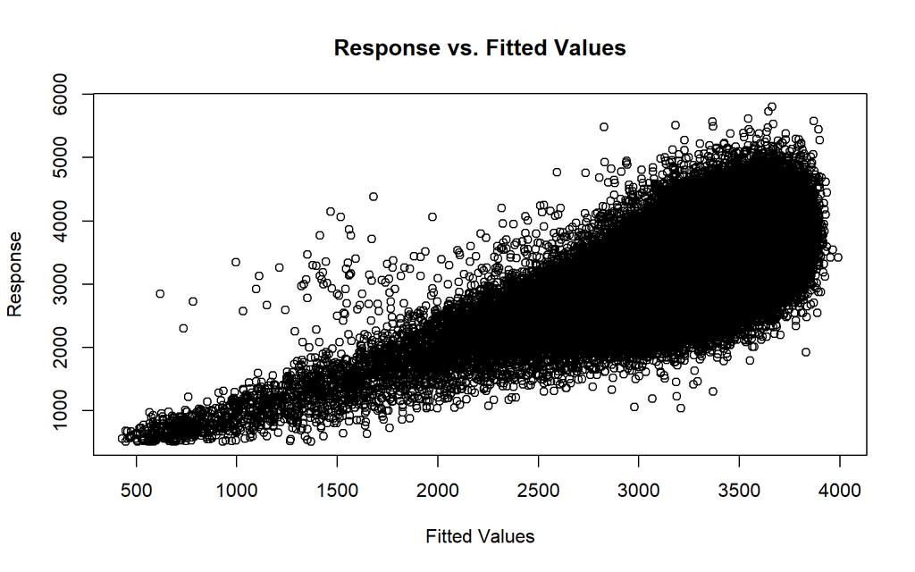

```
##
## Method: fREML   Optimizer: perf newton
## full convergence after 9 iterations.
## Gradient range [-0.003012899,0.00157634]
## (score 1625117 & scale 154851.4).
## Hessian positive definite, eigenvalue range [0.2965489,109886.5].
## Model rank =  38 / 38
##
## Basis dimension (k) checking results. Low p-value (k-index<1) may
## indicate that k is too low, especially if edf is close to k'.
##
##                    k'  edf k-index p-value
## s(GA_weeks)      9.00 8.25    1.00    0.54
## s(mat_age)       6.00 3.18    0.99    0.20
## s(birth_Y_M_num) 9.00 2.79    1.01    0.80
```

```r
  gam.check(m_BW_bam_2009_2)
```

```r
  concurvity(m_BW_bam_2009_2, full=TRUE) #values are now fine.
```

```
##               para s(GA_weeks) s(mat_age) s(birth_Y_M_num)
## worst    0.7977598 0.015480977 0.10374673      0.005498387
## observed 0.7977598 0.006357369 0.04511015      0.005110117
## estimate 0.7977598 0.009069121 0.06643985      0.003158472
```

```r
  #getting the CI 95%
  beta2 <- coef(m_BW_bam_2009_2)
  Vb2 <- vcov(m_BW_bam_2009_2, unconditional = TRUE)
  se2 <- sqrt(diag(Vb2))
  my.ci2 <- data.frame(cbind(beta2, lci = beta2-1.96*se2, uci = beta2 + 1.96*se2))
  round(head(my.ci2,14), 2)
```

```
##                                                        beta2     lci     uci
## (Intercept)                                          3330.03 3326.38 3333.69
## parity_cat(1,2]                                       121.45  117.76  125.15
## parity_cat(2,3]                                       170.53  164.89  176.17
## parity_cat(3,20]                                      193.63  184.00  203.25
## sex2                                                 -146.23 -149.52 -142.93
## Urban3                                                  3.38    0.01    6.75
## LanguageFrench                                        -50.35  -54.26  -46.44
## LanguageItalian                                       -69.23  -77.70  -60.77
## mother_nationality_cat2Africa                          41.10   29.27   52.94
## mother_nationality_cat2Asia                           -14.38  -24.06   -4.69
## mother_nationality_cat2Europe                          36.57   32.76   40.37
## mother_nationality_cat2Northern America                87.01   66.21  107.81
## mother_nationality_cat2Oceania                         58.13    9.19  107.07
## mother_nationality_cat2Southern and Central America    61.82   50.05   73.59
```

# 2017-2020

```r
m_BW_bam_covid <- bam(BW ~ s(GA_weeks) +  s(mat_age, k=7) + s(birth_Y_M_num) + s(month) + s(mean_ssep2) + parity_cat + sex + Urban3  + Language + mother_nationality_cat2, data=bevn_eco_in7_2017_20)
  summary(m_BW_bam_covid)
```

```
##
## Family: gaussian
## Link function: identity
##
## Formula:
## BW ~ s(GA_weeks) + s(mat_age, k = 7) + s(birth_Y_M_num) + s(month) +
##     s(mean_ssep2) + parity_cat + sex + Urban3 + Language + mother_nationality_cat2
##
## Parametric coefficients:
##                                                       Estimate Std. Error  t value Pr(>|t|)
## (Intercept)                                          3341.8206     1.5126 2209.339  < 2e-16 ***
## parity_cat(1,2]                                       132.5909     1.5035   88.188  < 2e-16 ***
## parity_cat(2,3]                                       180.8071     2.2931   78.847  < 2e-16 ***
## parity_cat(3,20]                                      202.2393     4.0023   50.531  < 2e-16 ***
## sex2                                                 -144.7288     1.3466 -107.477  < 2e-16 ***
## Urban3                                                 -0.1002     1.4225   -0.070  0.94387
## LanguageFrench                                        -51.2113     1.6328  -31.364  < 2e-16 ***
## LanguageItalian                                       -62.4804     3.9486  -15.824  < 2e-16 ***
## mother_nationality_cat2Africa                          -6.5741     3.7679   -1.745  0.08102 .
## mother_nationality_cat2Asia                           -16.4382     3.5459   -4.636 3.56e-06 ***
## mother_nationality_cat2Europe                          27.1944     1.5221   17.866  < 2e-16 ***
## mother_nationality_cat2Northern America                59.9037     9.0281    6.635 3.24e-11 ***
## mother_nationality_cat2Oceania                         60.9851    22.2865    2.736  0.00621 **
## mother_nationality_cat2Southern and Central America    38.2042     5.3668    7.119 1.09e-12 ***
## ---
## Signif. codes:  0 '***' 0.001 '**' 0.01 '*' 0.05 '.' 0.1 ' ' 1
##
## Approximate significance of smooth terms:
##                    edf Ref.df         F p-value
## s(GA_weeks)      8.501  8.906 22219.610  <2e-16 ***
## s(mat_age)       4.935  5.500    23.931  <2e-16 ***
## s(birth_Y_M_num) 5.402  6.270     9.357  <2e-16 ***
## s(month)         4.886  5.963     2.474  0.0227 *
## s(mean_ssep2)    5.064  6.232    14.994  <2e-16 ***
## ---
## Signif. codes:  0 '***' 0.001 '**' 0.01 '*' 0.05 '.' 0.1 ' ' 1
##
## R-sq.(adj) =  0.399   Deviance explained = 39.9%
## fREML = 2.4557e+06  Scale est. = 1.5056e+05  n = 332752
```

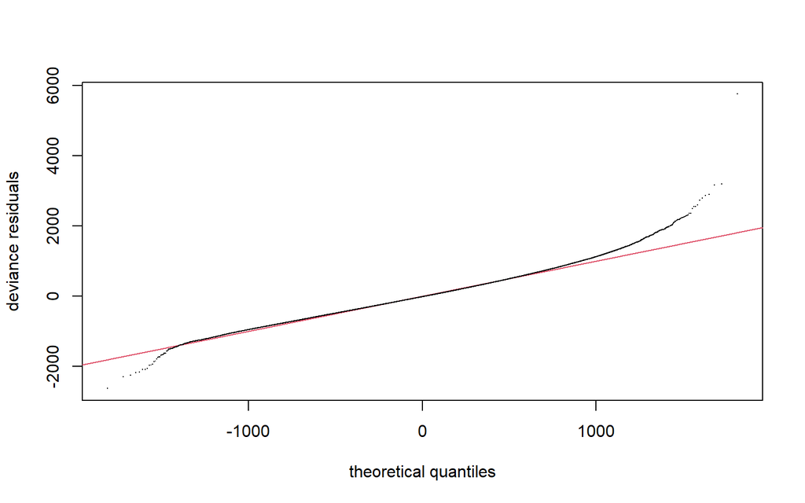

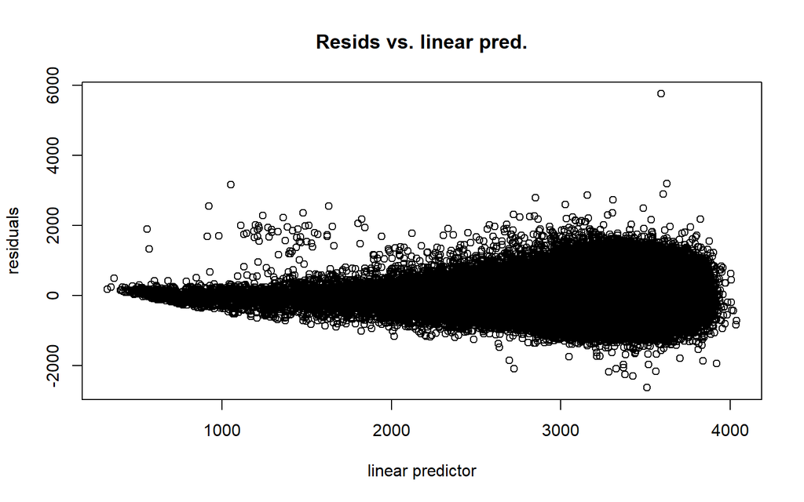

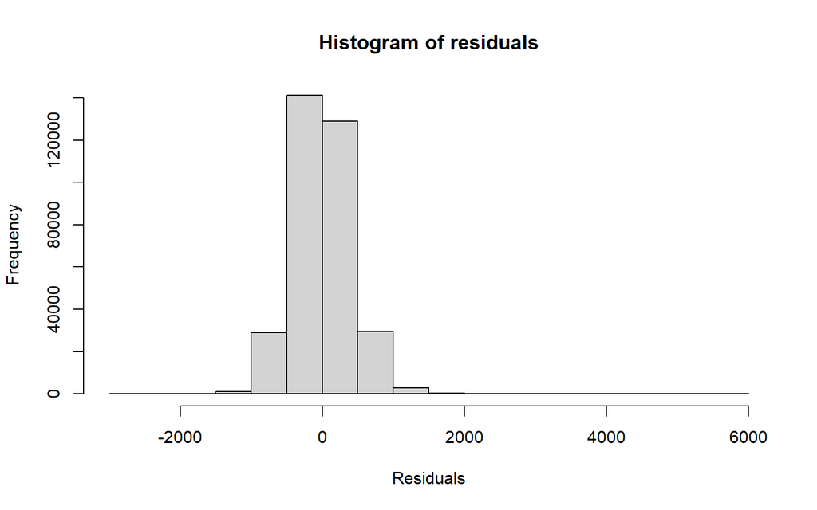

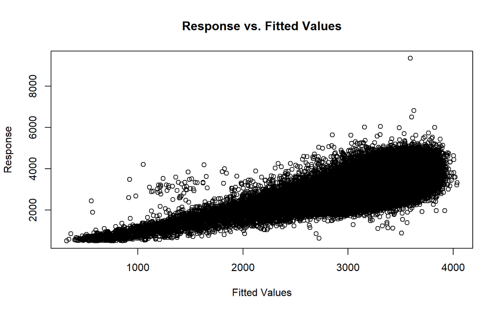

```
##
## Method: fREML   Optimizer: perf newton
## full convergence after 9 iterations.
## Gradient range [-0.02996079,0.01556609]
## (score 2455712 & scale 150562).
## Hessian positive definite, eigenvalue range [0.8410094,166366.5].
## Model rank =  56 / 56
##
## Basis dimension (k) checking results. Low p-value (k-index<1) may
## indicate that k is too low, especially if edf is close to k'.
##
##                    k'  edf k-index p-value
## s(GA_weeks)      9.00 8.50    0.99   0.175
## s(mat_age)       6.00 4.93    1.01   0.830
## s(birth_Y_M_num) 9.00 5.40    0.98   0.120
## s(month)         9.00 4.89    0.98   0.035 *
## s(mean_ssep2)    9.00 5.06    1.01   0.730
## ---
## Signif. codes:  0 '***' 0.001 '**' 0.01 '*' 0.05 '.' 0.1 ' ' 1
```

```r
  gam.check(m_BW_bam_covid)
```

```r
  concurvity(m_BW_bam_covid, full=TRUE)
```

```
##               para s(GA_weeks) s(mat_age) s(birth_Y_M_num)   s(month) s(mean_ssep2)
## worst    0.8025026 0.018824418 0.10874545       0.98667850 0.98667867    0.17781415
## observed 0.8025026 0.007294354 0.06211680       0.04431318 0.08573492    0.08814510
## estimate 0.8025026 0.010984418 0.06846027       0.04753634 0.71521628    0.08026843
```

Problem with birth_Y_M_num and month variables: values >>0.8, they correlate too much